# Week 5: Practical Example

# 1 Overview of the Week

This week, we’ll be reviewing what we’ve learned so far and applying it to a practical example. Our example is based on the paper [Individual differences in Fear of Missing Out (FoMO): Age, and the Big Five personality trait domains, facets, and items](https://www.sciencedirect.com/science/article/pii/S0191886920307376#ec0005). This paper looks at how fear of missing out (FOMO) is related to the Big Five personality traits, age, and gender. Although the data we will be using in these analysis are simulated, they are based on the data found in the paper. Because we haven’t yet covered linear modeling using categorical variables, the gender variable is replaced with a continuous variable that measures the number of followers participants have on Instagram.

We’re going to use these data to review simple linear models, multiple linear models, standardization, confidence intervals, and model evaluation and comparison.

# 2 Study Overview

## Description

### Research Question 1

Does age predict FOMO?

### Research Question 2

Does the total number of Instagram followers predict FOMO over and above age?

### Research Question 3

Does personality predict FOMO?

## Data Dictionary

[output not shown]

# 3 Setup

First, let’s load the data and all necessary packages:

```r
library(tidyverse)
library(psych)
library(kableExtra)
library(sjPlot)

dat <- read.csv('https://uoepsy.github.io/data/FOMOdataset.csv')
```

# 4 Checking the Data

Before we run any analyses, it’s a good idea to have a look at your data. You can check to make sure your data look the way you would expect them to. This lets you quickly identify and potentially correct any major issues with your data. There are lots of possible methods you could use, but in this example we’ll use the `summary` function, along with some histograms we’ll create using `ggplot`.

```r
dat %>%
  summary()
```

```
##       FOMO            Age              N               E
##  Min.   :10.00   Min.   :12.00   Min.   : 8.00   Min.   : 8.00
##  1st Qu.:20.00   1st Qu.:26.00   1st Qu.:19.00   1st Qu.:22.00
##  Median :25.00   Median :34.00   Median :23.00   Median :26.00
##  Mean   :24.63   Mean   :33.61   Mean   :22.92   Mean   :25.88
##  3rd Qu.:29.00   3rd Qu.:40.00   3rd Qu.:27.00   3rd Qu.:30.00
##  Max.   :46.00   Max.   :75.00   Max.   :40.00   Max.   :40.00
##        O               A               C         TotalFollowers
##  Min.   :14.00   Min.   :13.00   Min.   :13.00   Min.   :  1.0
##  1st Qu.:34.00   1st Qu.:27.00   1st Qu.:27.00   1st Qu.:135.0
##  Median :38.00   Median :31.00   Median :31.00   Median :199.0
##  Mean   :37.61   Mean   :30.89   Mean   :31.04   Mean   :203.3
##  3rd Qu.:42.00   3rd Qu.:34.00   3rd Qu.:35.00   3rd Qu.:267.0
##  Max.   :50.00   Max.   :43.00   Max.   :45.00   Max.   :594.0
```

`summary` will give us the range and the mean for each of our numeric variables, and also allow us to check whether our variables were imported in a way we would expect. Have a look to see whether everything looks ok (eg, are there any unexpected values, given the measurable range of scores?). In this example, the data are all clean and ready to use, but in future weeks (and in your dissertation), you’ll likely come across messier data and need to know how to handle it.

Next, we’ll create separate histograms for the `FOMO`, `Age`, and `TotalFollowers` variables. You can produce a single, basic histogram using the following code:

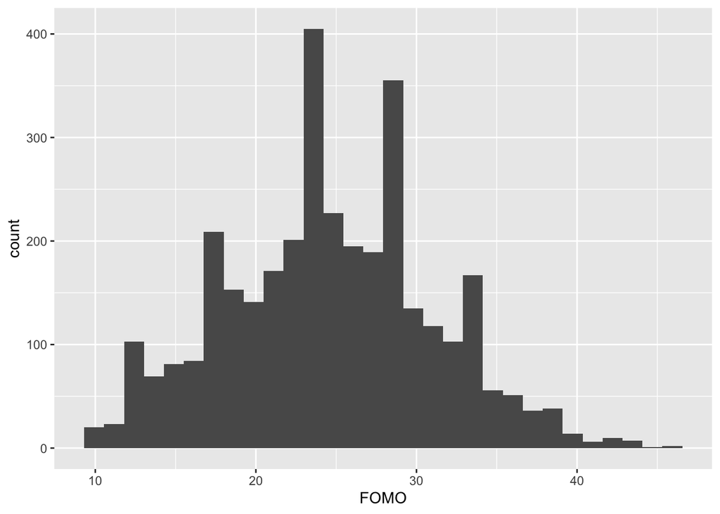

```r
ggplot(dat, aes(FOMO)) + geom_histogram()
```

We can alter the aesthetics to suit our preferences:

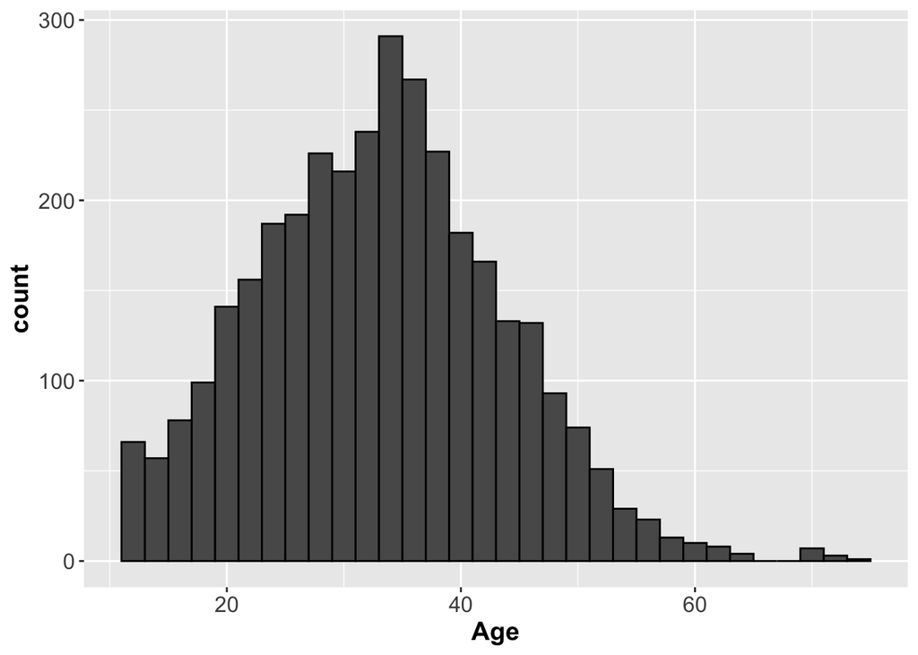

```r
ggplot(dat, aes(Age)) + geom_histogram(binwidth = 2, color='black') +
    theme(axis.title = element_text(size = 14, face='bold'),
        axis.text = element_text(size = 12))
```

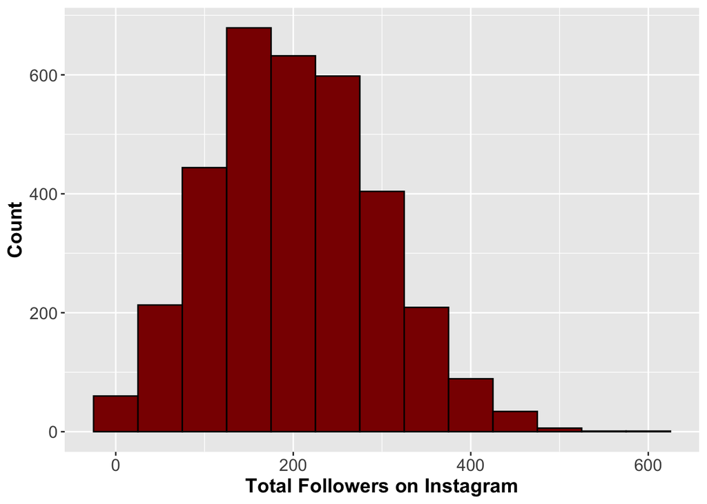

```r
ggplot(dat, aes(TotalFollowers)) +
  geom_histogram(binwidth = 50, color='black', fill='darkred') +
  labs(x="Total Followers on Instagram", y='Count') +
  theme(axis.title = element_text(size = 14, face='bold'),
        axis.text = element_text(size = 12))
```

We can also produce multiple histograms at once. This is especially useful if the variables reflect a similar theme (as is the case with our Big 5 data). To produce this grid of plots, you’ll first need to reformat the data slightly using the `gather` function, which converts the dataset into 2 columns - one with the original column names and another with the values from the columns. Note that I’m using `select` to pass only the Big 5 columns to `gather`.

```r
dat %>%
  select(c('O', 'C', 'E', 'A', 'N')) %>%
  gather() %>%
  head()
```

```
##   key value
## 1   O    32
## 2   O    33
## 3   O    36
## 4   O    37
## 5   O    41
## 6   O    31
```

The reformatted data can then be passed to `ggplot`, and the `facet_wrap` function can be used to group the data by the `key` variable (which contains the names of the original columns):

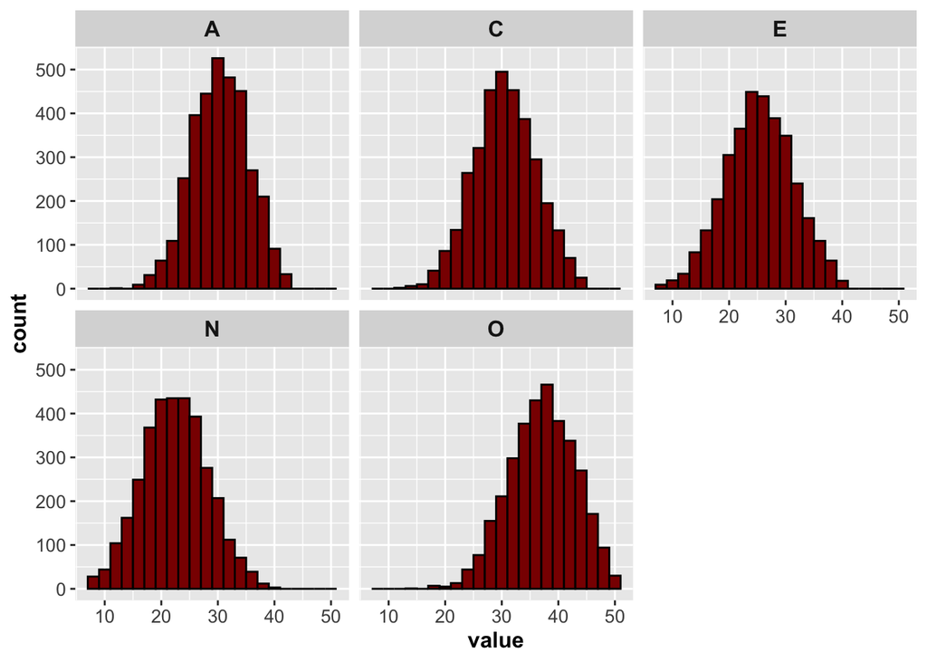

```r
dat %>%
  select(c('O', 'C', 'E', 'A', 'N')) %>%
  gather() %>%
    ggplot(., aes(value)) + geom_histogram(binwidth = 2, color='black', fill='darkred') +
    theme(axis.title = element_text(size = 12, face='bold'),
        axis.text = element_text(size = 10),
        strip.text = element_text(size = 12, face = 'bold')) +
    facet_wrap(~key)
```

We can also look at the association between each of our variables by producing scatterplots using the `pairs.panels` function from the `psych` package. This also provides another way to visualise each variable’s distribution.

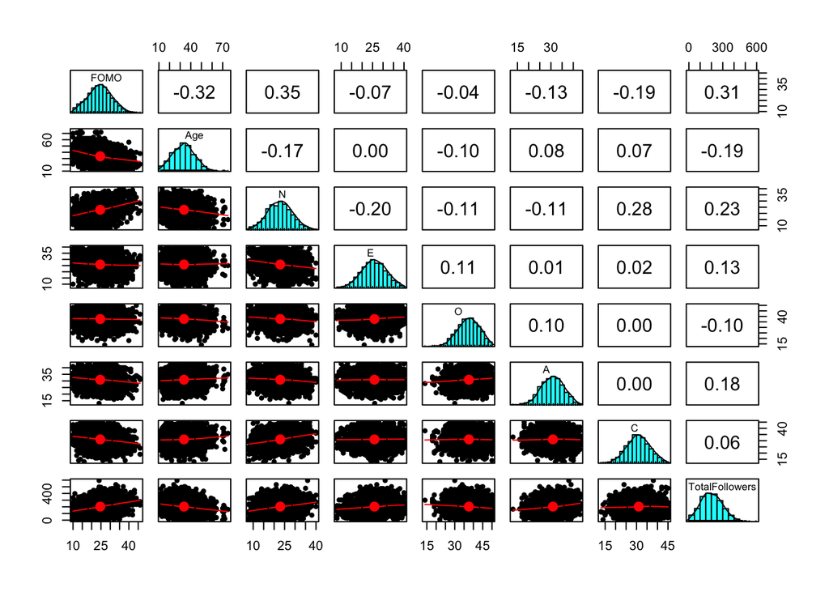

```r
pairs.panels(dat)
```

Typically, when we report our results, we need to present descriptive data about our variables. These are typically best presented in table format. Rather than individually calculating descriptive data for each variable, we can use the `describe` function to summarise the descriptives. Note the use of `rename` to adjust the column names.

```r
(descriptives <- dat %>%
  rename('Fear of Missing Out' = FOMO, 'Neuroticism' = N, 'Extraversion' = E,
         'Openness' = O, 'Agreeableness' = A, 'Conscientiousness' = C,
         'Total Instagram Followers' = TotalFollowers) %>%
  describe())
```

```
##                           vars    n   mean    sd median trimmed   mad min max
## Fear of Missing Out          1 3370  24.63  6.42     25   24.57  5.93  10  46
## Age                          2 3370  33.61 10.42     34   33.41 10.38  12  75
## Neuroticism                  3 3370  22.92  5.77     23   22.90  5.93   8  40
## Extraversion                 4 3370  25.88  5.94     26   25.91  5.93   8  40
## Openness                     5 3370  37.61  5.80     38   37.72  5.93  14  50
## Agreeableness                6 3370  30.89  4.93     31   30.92  4.45  13  43
## Conscientiousness            7 3370  31.04  5.49     31   31.05  5.93  13  45
## Total Instagram Followers    8 3370 203.25 93.42    199  200.73 96.37   1 594
##                           range  skew kurtosis   se
## Fear of Missing Out          36  0.12    -0.25 0.11
## Age                          63  0.25     0.00 0.18
## Neuroticism                  32  0.05    -0.26 0.10
## Extraversion                 32 -0.07    -0.27 0.10
## Openness                     36 -0.22    -0.25 0.10
## Agreeableness                30 -0.09    -0.29 0.08
## Conscientiousness            32 -0.04    -0.23 0.09
## Total Instagram Followers   593  0.28    -0.21 1.61
```

`describe`, from the `psych` package, produces a wide range of descriptive data. We won’t need to include all of it in our table. In this example, we’ll just produce a table with the mean and standard deviation of our variables. We can use the `select` function to specify our mean and standard deviation columns:

```r
descriptives %>%
  select(c('mean', 'sd')) %>%
  rename('Mean'= mean, 'SD' = sd) %>%
  kable(digits=2) %>%
  kable_styling(full_width = F) %>%
  column_spec(1, bold = T)
```

|  | Mean | SD |
| --- | --- | --- |
| Fear of Missing Out | 24.63 | 6.42 |
| Age | 33.61 | 10.42 |
| Neuroticism | 22.92 | 5.77 |
| Extraversion | 25.88 | 5.94 |
| Openness | 37.61 | 5.80 |
| Agreeableness | 30.89 | 4.93 |
| Conscientiousness | 31.04 | 5.49 |
| Total Instagram Followers | 203.25 | 93.42 |

# 5 Research Question 1

Now that we’ve looked over our data and confirmed everything looks ok, we can start to address our research questions. Our first question is **Does age predict fear of missing out?**

Before we run any analyses, we need to specify $\alpha$. We will set $\alpha=.05$ for all the following tests.

```r
m1 <- lm(FOMO~Age, dat)
summary(m1)
```

```
##
## Call:
## lm(formula = FOMO ~ Age, data = dat)
##
## Residuals:
##      Min       1Q   Median       3Q      Max
## -17.1028  -4.2129  -0.1602   4.0551  22.2321
##
## Coefficients:
##             Estimate Std. Error t value Pr(>|t|)
## (Intercept) 31.22239    0.35408   88.18   <2e-16 ***
## Age         -0.19617    0.01006  -19.50   <2e-16 ***
## ---
## Signif. codes:  0 '***' 0.001 '**' 0.01 '*' 0.05 '.' 0.1 ' ' 1
##
## Residual standard error: 6.084 on 3368 degrees of freedom
## Multiple R-squared:  0.1014, Adjusted R-squared:  0.1011
## F-statistic: 380.1 on 1 and 3368 DF,  p-value: < 2.2e-16
```

We can also compute the confidence interval for B1:

```r
confint(m1)
```

```
##                  2.5 %     97.5 %
## (Intercept) 30.5281496 31.9166293
## Age         -0.2158992 -0.1764425
```

What conclusions should we draw about RQ1?

# 6 Research Question 2

Next, we’ll investigate our second research question, **Does the total number of people one follows on Instagram predict FOMO over and above age?**

```r
m2 <- lm(FOMO~Age+TotalFollowers, dat)
anova(m1, m2)
```

```
## Analysis of Variance Table
##
## Model 1: FOMO ~ Age
## Model 2: FOMO ~ Age + TotalFollowers
##   Res.Df    RSS Df Sum of Sq      F    Pr(>F)
## 1   3368 124676
## 2   3367 115515  1    9161.4 267.04 < 2.2e-16 ***
## ---
## Signif. codes:  0 '***' 0.001 '**' 0.01 '*' 0.05 '.' 0.1 ' ' 1
```

What conclusions can we draw about RQ2?

```r
summary(m2)
```

```
##
## Call:
## lm(formula = FOMO ~ Age + TotalFollowers, data = dat)
##
## Residuals:
##     Min      1Q  Median      3Q     Max
## -17.273  -4.066  -0.071   3.841  21.705
##
## Coefficients:
##                 Estimate Std. Error t value Pr(>|t|)
## (Intercept)    26.521966   0.446021   59.46   <2e-16 ***
## Age            -0.165111   0.009871  -16.73   <2e-16 ***
## TotalFollowers  0.017989   0.001101   16.34   <2e-16 ***
## ---
## Signif. codes:  0 '***' 0.001 '**' 0.01 '*' 0.05 '.' 0.1 ' ' 1
##
## Residual standard error: 5.857 on 3367 degrees of freedom
## Multiple R-squared:  0.1674, Adjusted R-squared:  0.1669
## F-statistic: 338.6 on 2 and 3367 DF,  p-value: < 2.2e-16
```

```r
confint(m2)
```

```
##                      2.5 %      97.5 %
## (Intercept)    25.64746694 27.39646570
## Age            -0.18446526 -0.14575589
## TotalFollowers  0.01583102  0.02014788
```

# 7 Research Question 3

To address our 3rd research question, we use a different set of predictors: **Is personality a meaningful predictor of fear of missing out?** In this case, we will standardizing our variables:

```r
dat$FOMOz <- scale(dat$FOMO)
dat$Oz <- scale(dat$O)
dat$Cz <- scale(dat$C)
dat$Ez <- scale(dat$E)
dat$Az <- scale(dat$A)
dat$Nz <- scale(dat$N)
```

```r
m3 <- lm(FOMOz~Oz+Cz+Ez+Az+Nz, dat)
summary(m3)
```

```
##
## Call:
## lm(formula = FOMOz ~ Oz + Cz + Ez + Az + Nz, data = dat)
##
## Residuals:
##      Min       1Q   Median       3Q      Max
## -2.74061 -0.60648 -0.01036  0.59506  3.13402
##
## Coefficients:
##               Estimate Std. Error t value Pr(>|t|)
## (Intercept) -1.453e-17  1.527e-02   0.000    1.000
## Oz           1.117e-02  1.550e-02   0.721    0.471
## Cz          -3.079e-01  1.596e-02 -19.289  < 2e-16 ***
## Ez           1.744e-02  1.570e-02   1.111    0.267
## Az          -8.508e-02  1.544e-02  -5.511 3.83e-08 ***
## Nz           4.266e-01  1.643e-02  25.971  < 2e-16 ***
## ---
## Signif. codes:  0 '***' 0.001 '**' 0.01 '*' 0.05 '.' 0.1 ' ' 1
##
## Residual standard error: 0.8865 on 3364 degrees of freedom
## Multiple R-squared:  0.2152, Adjusted R-squared:  0.2141
## F-statistic: 184.5 on 5 and 3364 DF,  p-value: < 2.2e-16
```

```r
confint(m3)
```

```
##                   2.5 %      97.5 %
## (Intercept) -0.02994194  0.02994194
## Oz          -0.01921470  0.04155523
## Cz          -0.33916065 -0.27657348
## Ez          -0.01334388  0.04823358
## Az          -0.11535145 -0.05481487
## Nz           0.39441959  0.45883445
```

How should we interpret these results?

We might be interested in visualising the association between the significant predictors and the outcome variable in a bit more detail. We can do this using scatterplots:

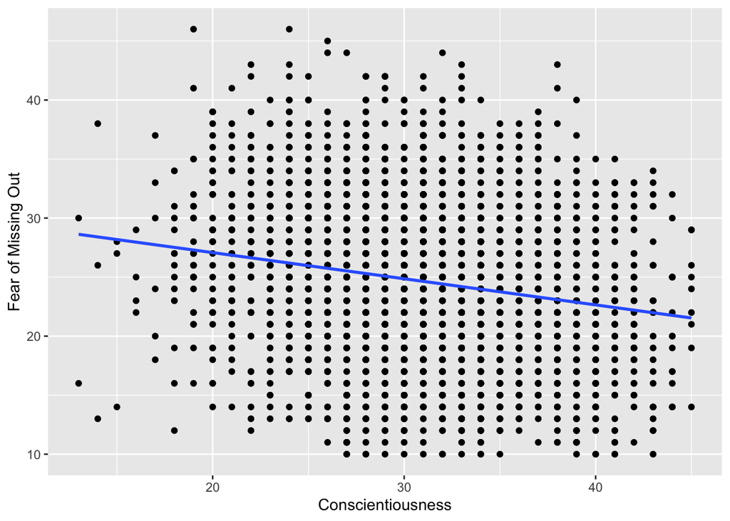

```r
ggplot(dat, aes(C, FOMO)) + geom_point() +
  geom_smooth(method = 'lm', se = F) +
  labs(x='Conscientiousness', y = 'Fear of Missing Out')
```

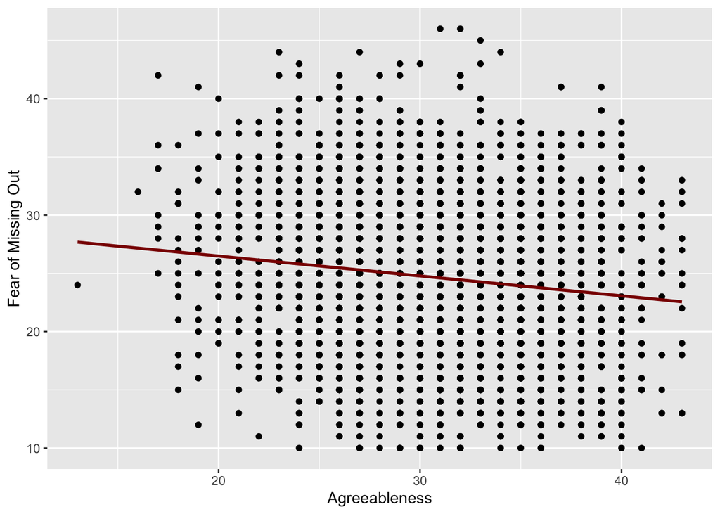

```r
ggplot(dat, aes(A, FOMO)) + geom_point() +
  geom_smooth(method = 'lm', se = F, colour = 'darkred') +
  labs(x='Agreeableness', y = 'Fear of Missing Out')
```

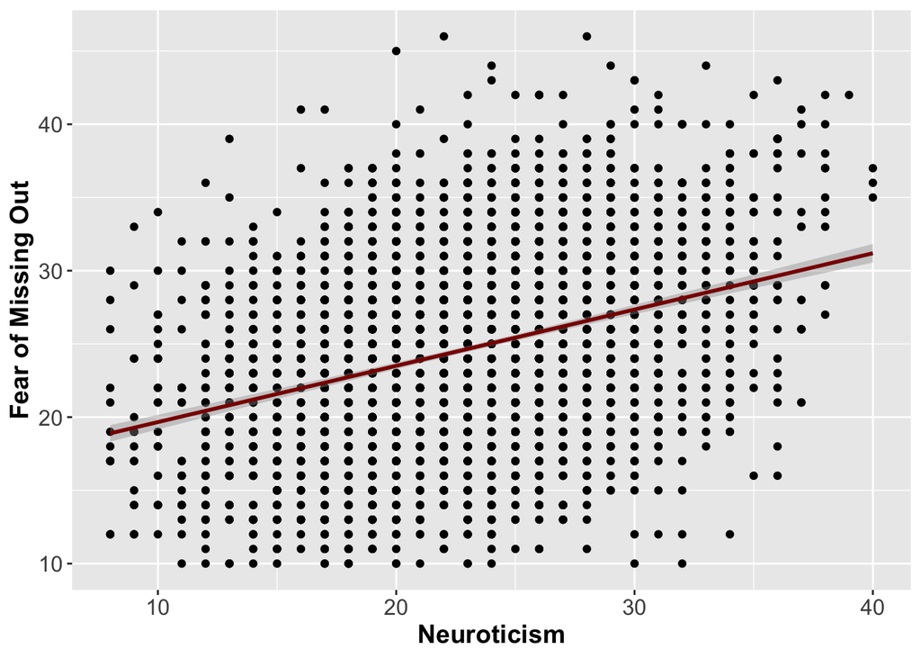

```r
ggplot(dat, aes(N, FOMO)) + geom_point() +
  geom_smooth(method = 'lm', colour ='darkred') +
  labs(x='Neuroticism', y = 'Fear of Missing Out') +
  theme(axis.text = element_text(size=12),
        axis.title = element_text(size = 14, face = 'bold'))
```

# 8 Bonus: Comparing models from RQ2 to RQ3

To compare between `m2` and `m3`, we can’t use an incremental F-test, since the models are non-nested. We can instead use AIC or BIC:

```r
AIC(m2, m3)
```

```
##    df       AIC
## m2  4 21482.868
## m3  7  8759.827
```

```r
BIC(m2, m3)
```

```
##    df       BIC
## m2  4 21507.359
## m3  7  8802.685
```

Which model seems to be a better fit?

# 9 Reporting the Results

In this analysis, we examined the effects of age, total number of Instagram followers, and personality characteristics on fear of missing out (FOMO). See Table 9.1 for descriptive data. $\alpha$ was set to .05 for all analyses.

Table 9.1: Descriptive Data

|  | Mean | SD |
| --- | --- | --- |
| Fear of Missing Out | 24.63 | 6.42 |
| Age | 33.61 | 10.42 |
| Neuroticism | 22.92 | 5.77 |
| Extraversion | 25.88 | 5.94 |
| Openness | 37.61 | 5.80 |
| Agreeableness | 30.89 | 4.93 |
| Conscientiousness | 31.04 | 5.49 |
| Total Instagram Followers | 203.25 | 93.42 |

There was a moderate negative association between FOMO and age and moderate positive associations between FoMO and Neuroticism and between FoMO and total Instagram followers. All other associations were weak. See Table 9.2 for correlation results.

Table 9.2: Associations Between Variables

|  | Fear of Missing Out | Age | Neuroticism | Extraversion | Openness | Agreeableness | Conscientiousness | Total Instagram Followers |
| --- | --- | --- | --- | --- | --- | --- | --- | --- |
| Fear of Missing Out | 1 |  |  |  |  |  |  |  |
| Age | -0.32 | 1 |  |  |  |  |  |  |
| Neuroticism | 0.35 | -0.17 | 1 |  |  |  |  |  |
| Extraversion | -0.07 | 0 | -0.2 | 1 |  |  |  |  |
| Openness | -0.04 | -0.1 | -0.11 | 0.11 | 1 |  |  |  |
| Agreeableness | -0.13 | 0.08 | -0.11 | 0.01 | 0.1 | 1 |  |  |
| Conscientiousness | -0.19 | 0.07 | 0.28 | 0.02 | 0 | 0 | 1 |  |
| Total Instagram Followers | 0.31 | -0.19 | 0.23 | 0.13 | -0.1 | 0.18 | 0.06 | 1 |

### Research Question 1

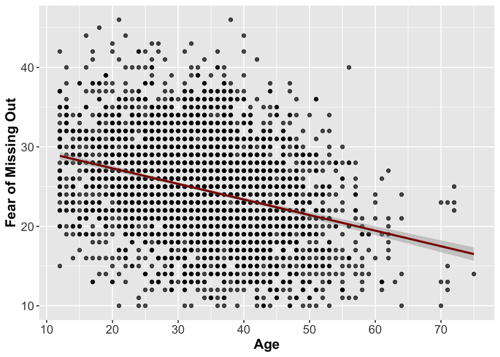

Figure 9.1: Association between Age and Fear of Missing Out

### Research Question 2

The total number of people one followed on Instagram predicted FOMO over and above age, $F(1, 3367)=267.04, p < .001$ (see Table 9.3). Together, age & Instagram followers explained 16.69% of the variance in FOMO scores. See Table 9.4 for results from the full model.

Table 9.3: Model Comparison Results

| Res.Df | RSS | Df | Sum of Sq | F | Pr(>F) |
| --- | --- | --- | --- | --- | --- |
| 3368 | 124676.4 | NA | NA | NA | NA |
| 3367 | 115515.0 | 1 | 9161.44 | 267.04 | 7.98e-58 |

Table 9.4: Instagram Following Model Results

|  | Fear of Missing Out |  |  |  |
| --- | --- | --- | --- | --- |
| Predictors | Estimates | std. Error | CI | p |
| Intercept | 26.52 | 0.45 | 25.65 – 27.40 | **<0.001** |
| Age | -0.17 | 0.01 | -0.18 – -0.15 | **<0.001** |
| Total Followers on Instagram | 0.02 | 0.00 | 0.02 – 0.02 | **<0.001** |
| Observations | 3370 |  |  |  |
| R<sup>2</sup> / R<sup>2</sup> adjusted | 0.167 / 0.167 |  |  |  |

### Research Question 3

Table 9.5: Personality Model Results

|  | Fear of Missing Out |  |  |  |
| --- | --- | --- | --- | --- |
| Predictors | Estimates | std. Error | CI | p |
| Intercept | -0.00 | 0.02 | -0.03 – 0.03 | 1.000 |
| Openness | 0.01 | 0.02 | -0.02 – 0.04 | 0.471 |
| Conscientiousness | -0.31 | 0.02 | -0.34 – -0.28 | **<0.001** |
| Extraversion | 0.02 | 0.02 | -0.01 – 0.05 | 0.267 |
| Agreeableness | -0.09 | 0.02 | -0.12 – -0.05 | **<0.001** |
| Neuroticism | 0.43 | 0.02 | 0.39 – 0.46 | **<0.001** |
| Observations | 3370 |  |  |  |
| R<sup>2</sup> / R<sup>2</sup> adjusted | 0.215 / 0.214 |  |  |  |